# Assignment 1 - Exploratory Data Analysis

## Data 622: Big Data and Machine Learning

### Dirk Hartog

```python
# Import packages

import pandas as pd
import seaborn as sns
import matplotlib.pyplot as plt
import numpy as np
```

# Data set 1

The first data set I will be looking at is the Parkinsons Disease Data set that can be found at [Kaggle.com](https://www.kaggle.com/datasets/rabieelkharoua/parkinsons-disease-dataset-analysis).

## Data Set Key

**Patient Information**

- Patient ID
  - PatientID: A unique identifier assigned to each patient (3058 to 5162).
- Demographic Details
  - Age: The age of the patients ranges from 50 to 90 years.
  - Gender: Gender of the patients, where 0 represents Male and 1 represents Female.
  - Ethnicity: The ethnicity of the patients, coded as follows:
    - 0: Caucasian
    - 1: African American
    - 2: Asian
    - 3: Other
  - EducationLevel: The education level of the patients, coded as follows:
    - 0: None
    - 1: High School
    - 2: Bachelor's
    - 3: Higher
- Lifestyle Factors
  - BMI: Body Mass Index of the patients, ranging from 15 to 40.
  - Smoking: Smoking status, where 0 indicates No and 1 indicates Yes.
  - AlcoholConsumption: Weekly alcohol consumption in units, ranging from 0 to 20.
  - PhysicalActivity: Weekly physical activity in hours, ranging from 0 to 10.
  - DietQuality: Diet quality score, ranging from 0 to 10.
  - SleepQuality: Sleep quality score, ranging from 4 to 10.

**Medical History**

- FamilyHistoryParkinsons: Family history of Parkinson's Disease, where 0 indicates No and 1 indicates Yes.
- TraumaticBrainInjury: History of traumatic brain injury, where 0 indicates No and 1 indicates Yes.
- Hypertension: Presence of hypertension, where 0 indicates No and 1 indicates Yes.
- Diabetes: Presence of diabetes, where 0 indicates No and 1 indicates Yes.
- Depression: Presence of depression, where 0 indicates No and 1 indicates Yes.
- Stroke: History of stroke, where 0 indicates No and 1 indicates Yes.

**Clinical Measurements**

- SystolicBP: Systolic blood pressure, ranging from 90 to 180 mmHg.
- DiastolicBP: Diastolic blood pressure, ranging from 60 to 120 mmHg.
- CholesterolTotal: Total cholesterol levels, ranging from 150 to 300 mg/dL.
- CholesterolLDL: Low-density lipoprotein cholesterol levels, ranging from 50 to 200 mg/dL.
- CholesterolHDL: High-density lipoprotein cholesterol levels, ranging from 20 to 100 mg/dL.
- CholesterolTriglycerides: Triglycerides levels, ranging from 50 to 400 mg/dL.

**Cognitive and Functional Assessments**

- UPDRS: Unified Parkinson's Disease Rating Scale score, ranging from 0 to 199. Higher scores indicate greater severity of the disease.
- MoCA: Montreal Cognitive Assessment score, ranging from 0 to 30. Lower scores indicate cognitive impairment.
- FunctionalAssessment: Functional assessment score, ranging from 0 to 10. Lower scores indicate greater impairment.

**Symptoms**

- Tremor: Presence of tremor, where 0 indicates No and 1 indicates Yes.
- Rigidity: Presence of muscle rigidity, where 0 indicates No and 1 indicates Yes.
- Bradykinesia: Presence of bradykinesia (slowness of movement), where 0 indicates No and 1 indicates Yes.
- PosturalInstability: Presence of postural instability, where 0 indicates No and 1 indicates Yes.
- SpeechProblems: Presence of speech problems, where 0 indicates No and 1 indicates Yes.
- SleepDisorders: Presence of sleep disorders, where 0 indicates No and 1 indicates Yes.
- Constipation: Presence of constipation, where 0 indicates No and 1 indicates Yes.

**Diagnosis Information**

- Diagnosis: Diagnosis status for Parkinson's Disease, where 0 indicates No and 1 indicates Yes.

**Confidential Information**

- DoctorInCharge: This column contains confidential information about the doctor in charge, with "DrXXXConfid" as the value for all patients.

```python
# Read in the data

data = pd.read_csv("https://raw.githubusercontent.com/D-hartog/DATA622/refs/heads/main/assignment1/parkinsons_disease_data.csv")
parkinsons_df = data.copy()
```

## Exploratory Data Analysis

```python
parkinsons_df.head()
```

|  | PatientID | Age | Gender | Ethnicity | EducationLevel | BMI | Smoking | AlcoholConsumption | PhysicalActivity | DietQuality | ... | FunctionalAssessment | Tremor | Rigidity | Bradykinesia | PosturalInstability | SpeechProblems | SleepDisorders | Constipation | Diagnosis | DoctorInCharge |
| --- | --- | --- | --- | --- | --- | --- | --- | --- | --- | --- | --- | --- | --- | --- | --- | --- | --- | --- | --- | --- | --- |
| 0 | 3058 | 85 | 0 | 3 | 1 | 19.619878 | 0 | 5.108241 | 1.380660 | 3.893969 | ... | 1.572427 | 1 | 0 | 0 | 0 | 0 | 0 | 0 | 0 | DrXXXConfid |
| 1 | 3059 | 75 | 0 | 0 | 2 | 16.247339 | 1 | 6.027648 | 8.409804 | 8.513428 | ... | 4.787551 | 0 | 1 | 0 | 1 | 0 | 1 | 0 | 1 | DrXXXConfid |
| 2 | 3060 | 70 | 1 | 0 | 0 | 15.368239 | 0 | 2.242135 | 0.213275 | 6.498805 | ... | 2.130686 | 1 | 0 | 0 | 0 | 1 | 0 | 1 | 1 | DrXXXConfid |
| 3 | 3061 | 52 | 0 | 0 | 0 | 15.454557 | 0 | 5.997788 | 1.375045 | 6.715033 | ... | 3.391288 | 1 | 1 | 1 | 0 | 0 | 0 | 1 | 1 | DrXXXConfid |
| 4 | 3062 | 87 | 0 | 0 | 1 | 18.616042 | 0 | 9.775243 | 1.188607 | 4.657572 | ... | 3.200969 | 0 | 0 | 0 | 1 | 0 | 1 | 0 | 0 | DrXXXConfid |

5 rows × 35 columns

```python
# Get information about features (Missing values and data types)

parkinsons_df.info()
```

```
<class 'pandas.core.frame.DataFrame'>
RangeIndex: 2105 entries, 0 to 2104
Data columns (total 35 columns):
 #   Column                    Non-Null Count  Dtype
---  ------                    --------------  -----
 0   PatientID                 2105 non-null   int64
 1   Age                       2105 non-null   int64
 2   Gender                    2105 non-null   int64
 3   Ethnicity                 2105 non-null   int64
 4   EducationLevel            2105 non-null   int64
 5   BMI                       2105 non-null   float64
 6   Smoking                   2105 non-null   int64
 7   AlcoholConsumption        2105 non-null   float64
 8   PhysicalActivity          2105 non-null   float64
 9   DietQuality               2105 non-null   float64
```

[output cut: 27 more lines]

```python
parkinsons_df.shape
```

```
(2105, 35)
```

```python
# Drop the "DoctorInCharge" as this feature does not add any predictive value
parkinsons_df.drop(columns= "DoctorInCharge", inplace = True)
```

```python
# There are many features that are categorical data types that need to be converted

cols_to_convert = ["Gender", "Ethnicity", "EducationLevel", "Smoking", "FamilyHistoryParkinsons",
                 "TraumaticBrainInjury", "Hypertension", "Diabetes", "Stroke", "Tremor", "Rigidity",
                 "Bradykinesia", "PosturalInstability", "SpeechProblems", "SleepDisorders", "Constipation",
                 "Diagnosis", "Depression"]

for col in cols_to_convert:
    parkinsons_df[col] = parkinsons_df[col].astype("object")
```

```python
# Recheck that those columns where converted
parkinsons_df.info()
```

```
<class 'pandas.core.frame.DataFrame'>
RangeIndex: 2105 entries, 0 to 2104
Data columns (total 34 columns):
 #   Column                    Non-Null Count  Dtype
---  ------                    --------------  -----
 0   PatientID                 2105 non-null   int64
 1   Age                       2105 non-null   int64
 2   Gender                    2105 non-null   object
 3   Ethnicity                 2105 non-null   object
 4   EducationLevel            2105 non-null   object
 5   BMI                       2105 non-null   float64
 6   Smoking                   2105 non-null   object
 7   AlcoholConsumption        2105 non-null   float64
 8   PhysicalActivity          2105 non-null   float64
 9   DietQuality               2105 non-null   float64
```

[output cut: 26 more lines]

After converting the features that original contained numeric data types into categorical values we have:

**No missing values**

```python
# Summary statistics on the numeric features

parkinsons_df.describe(include = ["int", "float"]).T
```

|  | count | mean | std | min | 25% | 50% | 75% | max |
| --- | --- | --- | --- | --- | --- | --- | --- | --- |
| PatientID | 2105.0 | 4110.000000 | 607.805479 | 3058.000000 | 3584.000000 | 4110.000000 | 4636.000000 | 5162.000000 |
| Age | 2105.0 | 69.601900 | 11.594511 | 50.000000 | 60.000000 | 70.000000 | 80.000000 | 89.000000 |
| BMI | 2105.0 | 27.209493 | 7.208099 | 15.008333 | 20.782176 | 27.184571 | 33.462452 | 39.999887 |
| AlcoholConsumption | 2105.0 | 10.040413 | 5.687014 | 0.002228 | 5.150278 | 10.070337 | 14.829565 | 19.988866 |
| PhysicalActivity | 2105.0 | 5.016674 | 2.890919 | 0.004157 | 2.455703 | 5.031550 | 7.512795 | 9.995255 |
| DietQuality | 2105.0 | 4.912901 | 2.872115 | 0.000011 | 2.478503 | 4.825187 | 7.381487 | 9.995864 |
| SleepQuality | 2105.0 | 6.996639 | 1.753065 | 4.000497 | 5.488864 | 6.929819 | 8.558719 | 9.999821 |
| SystolicBP | 2105.0 | 133.719715 | 26.502355 | 90.000000 | 110.000000 | 133.000000 | 157.000000 | 179.000000 |
| DiastolicBP | 2105.0 | 90.249881 | 17.061488 | 60.000000 | 75.000000 | 91.000000 | 105.000000 | 119.000000 |
| CholesterolTotal | 2105.0 | 226.860840 | 43.589406 | 150.062698 | 189.385178 | 228.528256 | 264.608100 | 299.963074 |
| CholesterolLDL | 2105.0 | 126.147858 | 43.407036 | 50.022828 | 88.841960 | 126.884570 | 163.912782 | 199.985981 |
| CholesterolHDL | 2105.0 | 59.670352 | 23.370920 | 20.027981 | 39.538643 | 59.343357 | 79.366628 | 99.982265 |
| CholesterolTriglycerides | 2105.0 | 222.940500 | 101.895822 | 50.113604 | 132.520174 | 222.802452 | 311.699109 | 399.975022 |
| UPDRS | 2105.0 | 101.415318 | 56.591448 | 0.028441 | 53.048148 | 102.561023 | 149.831682 | 198.953604 |
| MoCA | 2105.0 | 15.094314 | 8.643014 | 0.021191 | 7.517160 | 14.963574 | 22.608362 | 29.970107 |
| FunctionalAssessment | 2105.0 | 4.989694 | 2.933877 | 0.001505 | 2.415890 | 4.983227 | 7.484220 | 9.992697 |

```python
# Summary stats for all categorial features including the outcome variable
parkinsons_df.describe(include = "object").T
```

|  | count | unique | top | freq |
| --- | --- | --- | --- | --- |
| Gender | 2105 | 2 | 0 | 1068 |
| Ethnicity | 2105 | 4 | 0 | 1270 |
| EducationLevel | 2105 | 4 | 1 | 840 |
| Smoking | 2105 | 2 | 0 | 1481 |
| FamilyHistoryParkinsons | 2105 | 2 | 0 | 1798 |
| TraumaticBrainInjury | 2105 | 2 | 0 | 1881 |
| Hypertension | 2105 | 2 | 0 | 1798 |
| Diabetes | 2105 | 2 | 0 | 1793 |
| Depression | 2105 | 2 | 0 | 1673 |
| Stroke | 2105 | 2 | 0 | 2002 |
| Tremor | 2105 | 2 | 0 | 1196 |
| Rigidity | 2105 | 2 | 0 | 1573 |
| Bradykinesia | 2105 | 2 | 0 | 1668 |
| PosturalInstability | 2105 | 2 | 0 | 1813 |
| SpeechProblems | 2105 | 2 | 0 | 1484 |
| SleepDisorders | 2105 | 2 | 0 | 1589 |
| Constipation | 2105 | 2 | 0 | 1480 |
| Diagnosis | 2105 | 2 | 1 | 1304 |

## EDA Visualizations

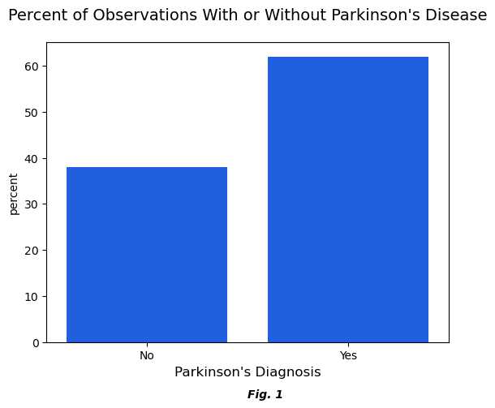

```python
# Look at the count of observations with Parkinsons and without Parkinsons

sns.countplot(data = parkinsons_df, x = parkinsons_df["Diagnosis"], stat = "percent", color = '#0056ff')
plt.xticks([0,1], ["No","Yes"])
plt.xlabel("Parkinson's Diagnosis", fontsize = 12)

plt.title("Percent of Observations With or Without Parkinson's Disease", fontsize = 14, pad = 20)
plt.text(x = 0.5, y = -12, s = "Fig. 1", fontstyle = "italic", fontweight = "demibold")
plt.show()
```

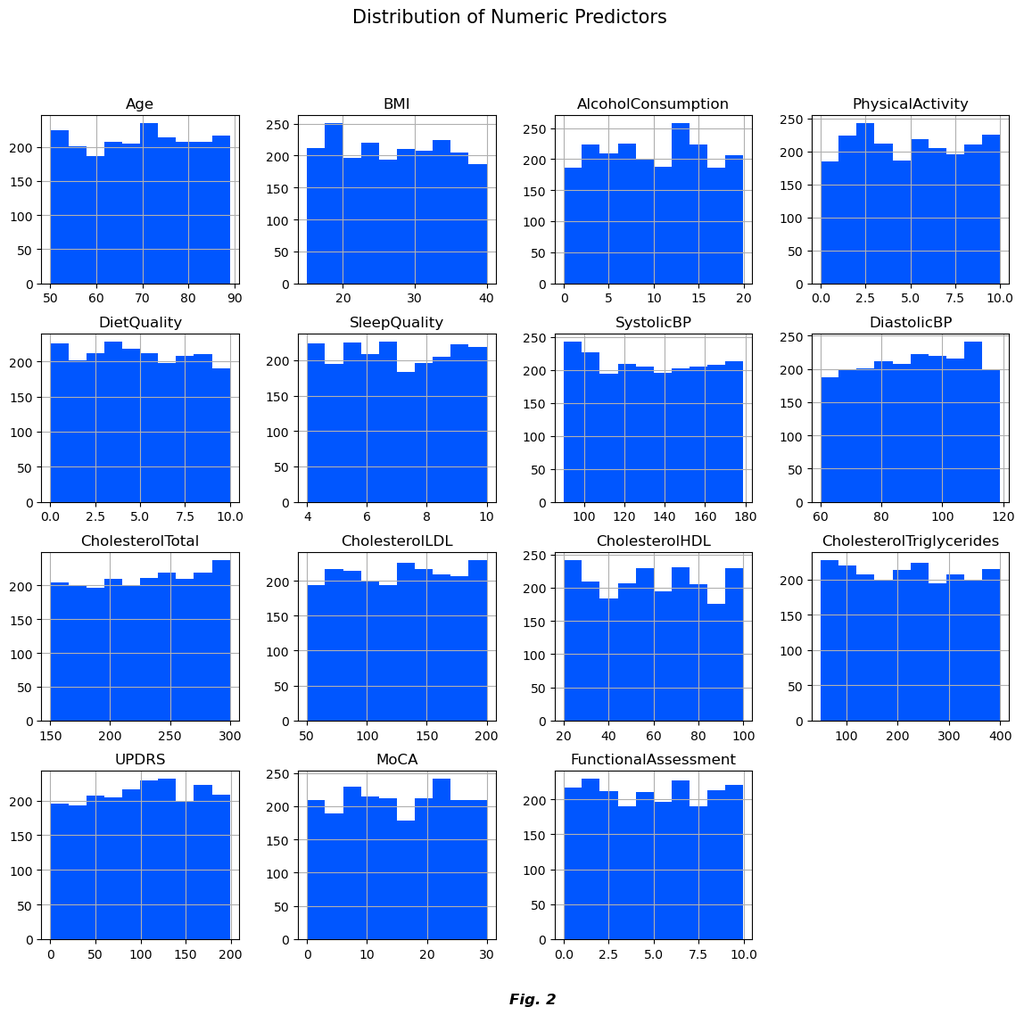

```python
# Create a histogram to visualize the distributions of the numeric variables
parkinsons_df.iloc[0:, 1:].hist(figsize = (14,12), layout=(4,4), color = '#0056ff')
plt.suptitle("Distribution of Numeric Predictors", fontsize = 15)
plt.figtext(x = 0.5, y = 0.05, s = "Fig. 2", fontstyle = "italic", fontweight = "demibold", fontsize = 12)
plt.show()
```

```python
# Visualize the correlations between numeric data types
parkinsons_numeric = parkinsons_df.select_dtypes(include = ["int", "float"])
corr = parkinsons_numeric.iloc[:,1:].corr()
corr
```

|  | Age | BMI | AlcoholConsumption | PhysicalActivity | DietQuality | SleepQuality | SystolicBP | DiastolicBP | CholesterolTotal | CholesterolLDL | CholesterolHDL | CholesterolTriglycerides | UPDRS | MoCA | FunctionalAssessment |
| --- | --- | --- | --- | --- | --- | --- | --- | --- | --- | --- | --- | --- | --- | --- | --- |
| Age | 1.000000 | 0.035622 | -0.009016 | 0.028100 | 0.012580 | 0.020866 | -0.017648 | 0.003578 | 0.020570 | 0.039681 | -0.014015 | 0.014923 | 0.007823 | -0.040081 | 0.039672 |
| BMI | 0.035622 | 1.000000 | 0.015542 | -0.003622 | 0.008020 | 0.017669 | -0.022107 | 0.006896 | 0.010158 | -0.019995 | -0.025793 | 0.026938 | 0.042895 | -0.017810 | -0.004586 |
| AlcoholConsumption | -0.009016 | 0.015542 | 1.000000 | 0.004530 | 0.007507 | 0.005871 | 0.002195 | -0.040023 | -0.021387 | -0.002003 | -0.001786 | -0.042412 | 0.025838 | -0.009050 | 0.002637 |
| PhysicalActivity | 0.028100 | -0.003622 | 0.004530 | 1.000000 | -0.017340 | -0.007859 | 0.009284 | -0.006053 | 0.017807 | -0.009559 | 0.017164 | 0.033488 | 0.012745 | -0.029015 | 0.010416 |
| DietQuality | 0.012580 | 0.008020 | 0.007507 | -0.017340 | 1.000000 | 0.041904 | 0.010411 | 0.001719 | 0.008308 | -0.004827 | 0.027148 | -0.017069 | 0.019461 | -0.008086 | 0.032041 |
| SleepQuality | 0.020866 | 0.017669 | 0.005871 | -0.007859 | 0.041904 | 1.000000 | -0.023922 | -0.045117 | 0.053631 | -0.024488 | 0.018683 | 0.010580 | -0.035224 | -0.011037 | 0.031218 |
| SystolicBP | -0.017648 | -0.022107 | 0.002195 | 0.009284 | 0.010411 | -0.023922 | 1.000000 | 0.022928 | -0.002874 | 0.006790 | 0.027366 | -0.020193 | 0.017682 | -0.001391 | 0.026013 |
| DiastolicBP | 0.003578 | 0.006896 | -0.040023 | -0.006053 | 0.001719 | -0.045117 | 0.022928 | 1.000000 | 0.004478 | -0.014595 | -0.008830 | -0.011899 | -0.025085 | 0.028928 | 0.025123 |
| CholesterolTotal | 0.020570 | 0.010158 | -0.021387 | 0.017807 | 0.008308 | 0.053631 | -0.002874 | 0.004478 | 1.000000 | 0.000094 | 0.026569 | -0.017274 | -0.021332 | -0.007572 | 0.004061 |
| CholesterolLDL | 0.039681 | -0.019995 | -0.002003 | -0.009559 | -0.004827 | -0.024488 | 0.006790 | -0.014595 | 0.000094 | 1.000000 | 0.036736 | 0.020995 | 0.004375 | 0.019266 | -0.010564 |
| CholesterolHDL | -0.014015 | -0.025793 | -0.001786 | 0.017164 | 0.027148 | 0.018683 | 0.027366 | -0.008830 | 0.026569 | 0.036736 | 1.000000 | 0.020501 | -0.045511 | -0.012435 | 0.000297 |
| CholesterolTriglycerides | 0.014923 | 0.026938 | -0.042412 | 0.033488 | -0.017069 | 0.010580 | -0.020193 | -0.011899 | -0.017274 | 0.020995 | 0.020501 | 1.000000 | 0.017247 | -0.009804 | 0.003563 |
| UPDRS | 0.007823 | 0.042895 | 0.025838 | 0.012745 | 0.019461 | -0.035224 | 0.017682 | -0.025085 | -0.021332 | 0.004375 | -0.045511 | 0.017247 | 1.000000 | -0.040235 | 0.000384 |
| MoCA | -0.040081 | -0.017810 | -0.009050 | -0.029015 | -0.008086 | -0.011037 | -0.001391 | 0.028928 | -0.007572 | 0.019266 | -0.012435 | -0.009804 | -0.040235 | 1.000000 | -0.003842 |
| FunctionalAssessment | 0.039672 | -0.004586 | 0.002637 | 0.010416 | 0.032041 | 0.031218 | 0.026013 | 0.025123 | 0.004061 | -0.010564 | 0.000297 | 0.003563 | 0.000384 | -0.003842 | 1.000000 |

Evaluate for the presence of multicollinearity.

- Build a correlation plot to visualize the correlation coefficients between numeric variables
- Antoher approach is use teh variance inflation factor - an VIF > 5 indicates the presence of multicollinearity

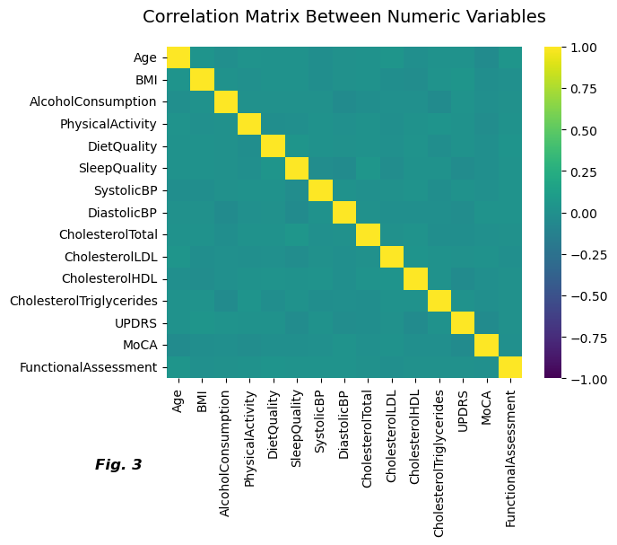

```python
# Create heatmap to visualize the correlation strength bewteen numeric variables

sns.heatmap(corr, vmin=-1, vmax= 1, center = 0, cmap="viridis")
plt.title("Correlation Matrix Between Numeric Variables", pad = 20, fontsize = 14)
plt.figtext(x = 0, y = -0.1, s = "Fig. 3", fontstyle = "italic", fontweight = "demibold", fontsize = 12)
plt.show()
```

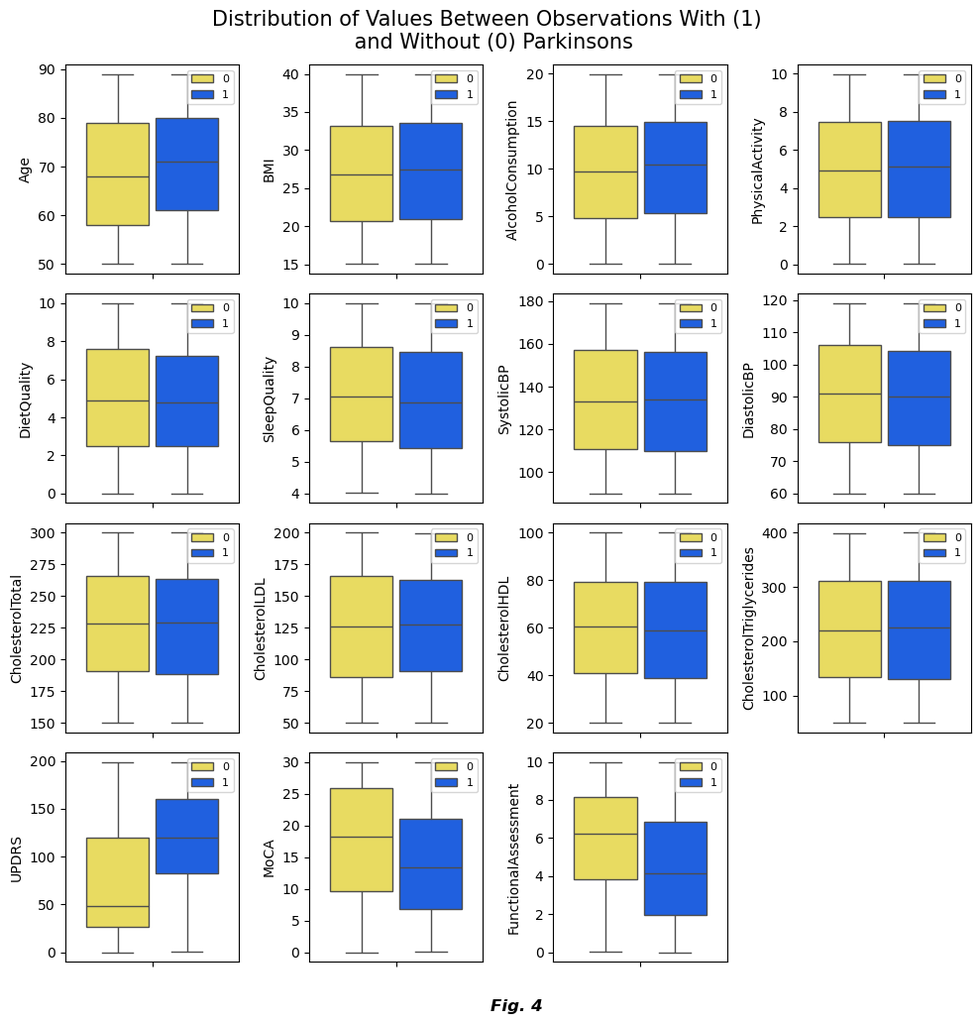

```python
# Visualize the distributions of the numeric data between observations with and without parkinsons with box plots

num_columns = parkinsons_numeric.iloc[0:, 1:].columns

plt.figure(figsize = (10,10))

for i in range(len(num_columns)):
    plt.subplot(4,4,i+1)
    sns.boxplot(data = parkinsons_numeric.iloc[0:, 1:],
                  y = num_columns[i],
                  hue = parkinsons_df["Diagnosis"],
                  palette = ['#ffed4a', '#0056ff'],
               dodge = True,
               gap = 0.1)

    plt.legend(fontsize = 8, loc = 'upper right')

plt.suptitle("Distribution of Values Between Observations With (1) \n and Without (0) Parkinsons",
            fontsize = 15)
plt.tight_layout()
plt.figtext(x = 0.5, y = -0.03, s = "Fig. 4", fontstyle = "italic", fontweight = "demibold", fontsize = 12)
plt.show()
```

```python
# Create a seperate data frame with all catergorical variables to visualize counts between classes
# - include stratification by diagnosis

parkinsons_cat = parkinsons_df.select_dtypes(include = "object")
```

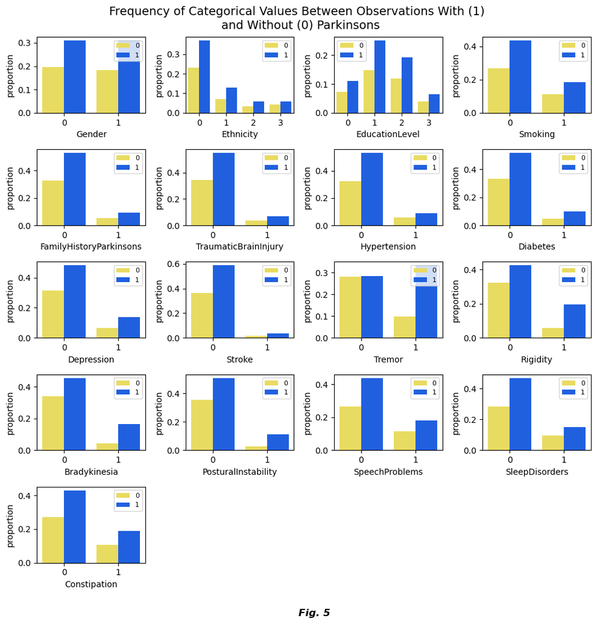

```python
# Visualize the counts of cateforical data - 5 rows, 4 columns

# Create variable with categorical columns
cat_columns = parkinsons_cat.columns

# Create plot
plt.figure(figsize = (10,10))

for i in range(len(parkinsons_cat.columns) - 1):
    plt.subplot(5,4,i+1)
    sns.countplot(data = parkinsons_cat,
                  x = cat_columns[i],
                  hue = cat_columns[-1],
                  palette = ['#ffed4a', '#0056ff'], stat = "proportion")
    plt.legend(fontsize = 8)

plt.suptitle("Frequency of Categorical Values Between Observations With (1) \n and Without (0) Parkinsons",
            fontsize = 14)
plt.figtext(x = 0.5, y = -0.03, s = "Fig. 5", fontstyle = "italic", fontweight = "demibold", fontsize = 12)
plt.tight_layout()
```

```python
# Frequency table between the diagnosis and all of the categorical features
# Might be useful to reference the actual values

cat_freq_table = parkinsons_cat.melt(id_vars = "Diagnosis",
                    value_vars = parkinsons_cat.columns[0:len(parkinsons_cat.columns)-1],
                   var_name = "Variable",
                   value_name = "Presence").groupby(["Diagnosis","Variable"])["Presence"].value_counts()
cat_freq_table
```

```
Diagnosis  Variable              Presence
0          Bradykinesia          0            711
                                 1             90
           Constipation          0            575
                                 1            226
           Depression            0            661
                                             ...
1          Stroke                1             70
           TraumaticBrainInjury  0           1158
                                 1            146
           Tremor                1            702
                                 0            602
Name: Presence, Length: 76, dtype: int64
```

```python
cat_freq_table.loc[0:,"Tremor"]
```

```
Diagnosis  Variable  Presence
0          Tremor    0           594
                     1           207
1          Tremor    1           702
                     0           602
Name: Presence, dtype: int64
```

## Modelling: Logistic Regression

```python
# Import necessary libraries

from sklearn.model_selection import train_test_split
from sklearn.linear_model import LogisticRegression
from sklearn.preprocessing import StandardScaler
from sklearn.metrics import f1_score, recall_score, accuracy_score, precision_score
from sklearn.metrics import confusion_matrix, ConfusionMatrixDisplay
```

```python
parkinsons_df.info()
```

```
<class 'pandas.core.frame.DataFrame'>
RangeIndex: 2105 entries, 0 to 2104
Data columns (total 34 columns):
 #   Column                    Non-Null Count  Dtype
---  ------                    --------------  -----
 0   PatientID                 2105 non-null   int64
 1   Age                       2105 non-null   int64
 2   Gender                    2105 non-null   object
 3   Ethnicity                 2105 non-null   object
 4   EducationLevel            2105 non-null   object
 5   BMI                       2105 non-null   float64
 6   Smoking                   2105 non-null   object
 7   AlcoholConsumption        2105 non-null   float64
 8   PhysicalActivity          2105 non-null   float64
 9   DietQuality               2105 non-null   float64
```

[output cut: 26 more lines]

```python
# Convert categorical features back to numeric

parkinsons_df[cat_columns] = parkinsons_df[cat_columns].astype("int")

# Split the data into two sets
# X is our features
# y is our target/dependent variable

X = parkinsons_df.drop(["Diagnosis", "PatientID"], axis = 1).values
y = parkinsons_df["Diagnosis"].values
```

```python
# Create testing and training data sets

X_train, X_test, y_train, y_test = train_test_split(X, y, test_size=0.3, random_state=123, stratify=y)
```

```python
# Create a logistic regression object
logreg = LogisticRegression(solver = 'liblinear', max_iter = 1000)

# Fit the classifier to the training data
#logreg.fit(X_train, y_train)

model = logreg.fit(X_train, y_train)

# Predict values
y_pred = model.predict(X_test)
```

### Model prediction and evaluation

```python
# We can predict probabilities of each instance belonging to a class by calling logistic regression's
# predict_proba method and passing the test features

predict_probs = model.predict_proba(X_test)
```

```python
print(len(predict_probs))
```

```
632
```

```python
# Create a data frame to visualize the actual and predicted values and the probabilities of the predicted values

predict_probs_df = pd.DataFrame(predict_probs, columns = parkinsons_df["Diagnosis"].unique())
outcome_class = pd.DataFrame({"Actual Values" : y_test, "Predicted Values" : y_pred})

pd.merge(outcome_class, predict_probs_df, right_index = True, left_index = True).head(10)
```

|  | Actual Values | Predicted Values | 0 | 1 |
| --- | --- | --- | --- | --- |
| 0 | 0 | 1 | 0.263614 | 0.736386 |
| 1 | 0 | 1 | 0.456924 | 0.543076 |
| 2 | 1 | 1 | 0.002375 | 0.997625 |
| 3 | 1 | 1 | 0.009949 | 0.990051 |
| 4 | 0 | 1 | 0.337404 | 0.662596 |
| 5 | 0 | 0 | 0.689770 | 0.310230 |
| 6 | 0 | 0 | 0.993575 | 0.006425 |
| 7 | 0 | 0 | 0.542660 | 0.457340 |
| 8 | 0 | 0 | 0.877076 | 0.122924 |
| 9 | 1 | 1 | 0.062111 | 0.937889 |

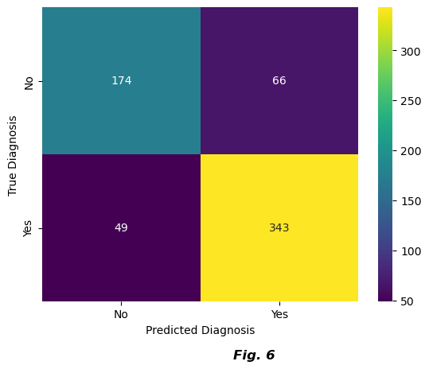

```python
# Confusion Matrix

con_mat = confusion_matrix(y_true = y_test,
                           y_pred = y_pred, labels = model.classes_)
sns.heatmap(con_mat, annot=True,
           xticklabels = ["No", "Yes"],
           yticklabels = ["No", "Yes"],
           fmt="d",
           cmap="viridis")

# Set labels so they are not in exponential form
plt.ylabel("True Diagnosis")
plt.xlabel("Predicted Diagnosis")
plt.figtext(x = 0.5, y = -0.04, s = "Fig. 6", fontstyle = "italic", fontweight = "demibold", fontsize = 12)
plt.show()
```

```python
# F1 Score

print("F1 score: ", f1_score(y_test, y_pred))

# Sensitivity - True Positive Rate - (TP/TP + FN)
# How many TP the model labeled incorrectly
print("Recall score: ", recall_score(y_test, y_pred))

# Precision -  Accuracy of predicting a predicted postive outcome (TP / TP + FP)
# How many Predicted positives were wrong
print("Precision score: ", precision_score(y_test, y_pred))

# Specificity - The proportion of negative classes that were correctly classified as negative (TN / TN + FP)
print("Specificity score: ", con_mat[0,0]/(con_mat[0,0] + con_mat[0,1]))

# Accuracy - The percent or proportion of cases classified corectly
print("Accuracy score: ", accuracy_score(y_test, y_pred))
```

```
F1 score:  0.8564294631710362
Recall score:  0.875
Precision score:  0.8386308068459658
Specificity score:  0.725
Accuracy score:  0.8180379746835443
```

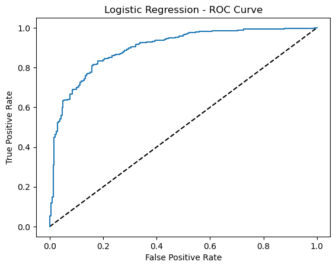

```python
from sklearn.metrics import roc_curve

# fpr = false positive rate
# tpr = true positive rate
# thresholds

fpr, tpr, thresholds, = roc_curve(y_test, predict_probs[:,1])
plt.plot([0,1], [0,1], 'k--')
plt.plot(fpr, tpr)
plt.xlabel('False Positive Rate')
plt.ylabel('True Positive Rate')
plt.title('Logistic Regression - ROC Curve')
plt.show()
```

```python
from sklearn.metrics import roc_auc_score

print(roc_auc_score(y_test, predict_probs[:,1]))
```

```
0.8984481292517007
```

```python
# Lookign the multicollinearity of the predictor variabls
from statsmodels.stats.outliers_influence import variance_inflation_factor

print("VIF_age: ", variance_inflation_factor(X_test, 0))
```

```
VIF_age:  32.742523865686955
```

```python
# Calculate the VIF for each variable in the original data set

# creating dummies for gender
#data['Gender'] = data['Gender'].map({'Male':0, 'Female':1})

# the independent variables set
X = parkinsons_numeric.iloc[:,1:]

# VIF dataframe
vif_data = pd.DataFrame()
vif_data["feature"] = X.columns

# calculating VIF for each feature
vif_data["VIF"] = [variance_inflation_factor(X.values, i)
                          for i in range(len(X.columns))]

print(vif_data)
```

```
                     feature        VIF
0                        Age  30.790467
1                        BMI  14.306566
2         AlcoholConsumption   4.038294
3           PhysicalActivity   3.981288
4                DietQuality   3.910700
5               SleepQuality  15.679514
6                 SystolicBP  22.782773
7                DiastolicBP  24.446391
8           CholesterolTotal  24.548810
9             CholesterolLDL   9.104828
10            CholesterolHDL   7.351152
11  CholesterolTriglycerides   5.676786
12                     UPDRS   4.166657
13                      MoCA   3.974363
14      FunctionalAssessment   3.889980
```

# Data set 2

The second data set was also found on [Kaggle.](https://www.kaggle.com/datasets/wajahat1064/healthcare-appointment-dataset)

```python
hospital_no_shows = pd.read_csv("https://raw.githubusercontent.com/D-hartog/DATA622/refs/heads/main/assignment1/healthcare_noshows_appointments.csv")
hospital_no_shows.head()
```

|  | PatientId | AppointmentID | Gender | ScheduledDay | AppointmentDay | Age | Neighbourhood | Scholarship | Hipertension | Diabetes | Alcoholism | Handcap | SMS_received | Showed_up | Date.diff |
| --- | --- | --- | --- | --- | --- | --- | --- | --- | --- | --- | --- | --- | --- | --- | --- |
| 0 | 2.987250e+13 | 5642903 | F | 2016-04-29 | 2016-04-29 | 62 | JARDIM DA PENHA | False | True | False | False | False | False | True | 0 |
| 1 | 5.589978e+14 | 5642503 | M | 2016-04-29 | 2016-04-29 | 56 | JARDIM DA PENHA | False | False | False | False | False | False | True | 0 |
| 2 | 4.262962e+12 | 5642549 | F | 2016-04-29 | 2016-04-29 | 62 | MATA DA PRAIA | False | False | False | False | False | False | True | 0 |
| 3 | 8.679512e+11 | 5642828 | F | 2016-04-29 | 2016-04-29 | 8 | PONTAL DE CAMBURI | False | False | False | False | False | False | True | 0 |
| 4 | 8.841186e+12 | 5642494 | F | 2016-04-29 | 2016-04-29 | 56 | JARDIM DA PENHA | False | True | True | False | False | False | True | 0 |

## Exploratory Data Analysis

```python
hospital_no_shows.info()
```

```
<class 'pandas.core.frame.DataFrame'>
RangeIndex: 106987 entries, 0 to 106986
Data columns (total 15 columns):
 #   Column          Non-Null Count   Dtype
---  ------          --------------   -----
 0   PatientId       106987 non-null  float64
 1   AppointmentID   106987 non-null  int64
 2   Gender          106987 non-null  object
 3   ScheduledDay    106987 non-null  object
 4   AppointmentDay  106987 non-null  object
 5   Age             106987 non-null  int64
 6   Neighbourhood   106987 non-null  object
 7   Scholarship     106987 non-null  bool
 8   Hipertension    106987 non-null  bool
 9   Diabetes        106987 non-null  bool
 10  Alcoholism      106987 non-null  bool
 11  Handcap         106987 non-null  bool
 12  SMS_received    106987 non-null  bool
 13  Showed_up       106987 non-null  bool
 14  Date.diff       106987 non-null  int64
dtypes: bool(7), float64(1), int64(3), object(4)
memory usage: 7.2+ MB
```

```python
# Copy original date frame and drop the patient id and appointment id
no_show_data = hospital_no_shows.copy()
no_show_data = no_show_data.drop(columns = ["PatientId", "AppointmentID"])
```

```python
no_show_data.info()
```

```
<class 'pandas.core.frame.DataFrame'>
RangeIndex: 106987 entries, 0 to 106986
Data columns (total 13 columns):
 #   Column          Non-Null Count   Dtype
---  ------          --------------   -----
 0   Gender          106987 non-null  object
 1   ScheduledDay    106987 non-null  object
 2   AppointmentDay  106987 non-null  object
 3   Age             106987 non-null  int64
 4   Neighbourhood   106987 non-null  object
 5   Scholarship     106987 non-null  bool
 6   Hipertension    106987 non-null  bool
 7   Diabetes        106987 non-null  bool
 8   Alcoholism      106987 non-null  bool
 9   Handcap         106987 non-null  bool
 10  SMS_received    106987 non-null  bool
 11  Showed_up       106987 non-null  bool
 12  Date.diff       106987 non-null  int64
dtypes: bool(7), int64(2), object(4)
memory usage: 5.6+ MB
```

```python
no_show_data.head()
```

|  | Gender | ScheduledDay | AppointmentDay | Age | Neighbourhood | Scholarship | Hipertension | Diabetes | Alcoholism | Handcap | SMS_received | Showed_up | Date.diff |
| --- | --- | --- | --- | --- | --- | --- | --- | --- | --- | --- | --- | --- | --- |
| 0 | F | 2016-04-29 | 2016-04-29 | 62 | JARDIM DA PENHA | False | True | False | False | False | False | True | 0 |
| 1 | M | 2016-04-29 | 2016-04-29 | 56 | JARDIM DA PENHA | False | False | False | False | False | False | True | 0 |
| 2 | F | 2016-04-29 | 2016-04-29 | 62 | MATA DA PRAIA | False | False | False | False | False | False | True | 0 |
| 3 | F | 2016-04-29 | 2016-04-29 | 8 | PONTAL DE CAMBURI | False | False | False | False | False | False | True | 0 |
| 4 | F | 2016-04-29 | 2016-04-29 | 56 | JARDIM DA PENHA | False | True | True | False | False | False | True | 0 |

```python
# Convert True/False values to "Yes"/"No"

no_show_data.replace([True, False], ["Yes", "No"], inplace = True)
```

```python
# Summary Statistics for numeric variables

no_show_data.describe().T
```

|  | count | mean | std | min | 25% | 50% | 75% | max |
| --- | --- | --- | --- | --- | --- | --- | --- | --- |
| Age | 106987.0 | 38.316085 | 22.466214 | 1.0 | 19.0 | 38.0 | 56.0 | 115.0 |
| Date.diff | 106987.0 | 10.166721 | 15.263508 | -6.0 | 0.0 | 4.0 | 14.0 | 179.0 |

```python
no_show_data.describe(include = ["object", "bool"]).T
```

|  | count | unique | top | freq |
| --- | --- | --- | --- | --- |
| Gender | 106987 | 2 | F | 70118 |
| ScheduledDay | 106987 | 110 | 2016-05-03 | 4076 |
| AppointmentDay | 106987 | 27 | 2016-06-06 | 4528 |
| Neighbourhood | 106987 | 81 | JARDIM CAMBURI | 7586 |
| Scholarship | 106987 | 2 | No | 96178 |
| Hipertension | 106987 | 2 | No | 85186 |
| Diabetes | 106987 | 2 | No | 99044 |
| Alcoholism | 106987 | 2 | No | 103627 |
| Handcap | 106987 | 2 | No | 104747 |
| SMS_received | 106987 | 2 | No | 72402 |
| Showed_up | 106987 | 2 | Yes | 85307 |

```python
# Convert the data types for ScheduledDay and AppointmentDay to pandas dattime objects

no_show_data["ScheduledDay"] = pd.to_datetime(no_show_data["ScheduledDay"])
no_show_data["AppointmentDay"] = pd.to_datetime(no_show_data["AppointmentDay"])
```

```python
# Find the min and max values
print("Start date: ", no_show_data["AppointmentDay"].min().date())
print("End date: ", no_show_data["AppointmentDay"].max().date())
```

```
Start date:  2016-04-29
End date:  2016-06-08
```

```python
# Exapnd the ScheduledDay and AppoiontmentDay to extract the day of the week
no_show_data["AppointmentWeekDay"] = no_show_data["AppointmentDay"].dt.day_name()
no_show_data["ScheduledWeekDay"] = no_show_data["ScheduledDay"].dt.day_name()
```

```python
# Visualize the frequency of cancellations between Neighborhoods, SMS Received, Gender and AppointmentWeekDay

no_show_data[["Neighbourhood", "SMS_received", "Gender", "AppointmentWeekDay", "Showed_up"]]
```

|  | Neighbourhood | SMS_received | Gender | AppointmentWeekDay | Showed_up |
| --- | --- | --- | --- | --- | --- |
| 0 | JARDIM DA PENHA | No | F | Friday | Yes |
| 1 | JARDIM DA PENHA | No | M | Friday | Yes |
| 2 | MATA DA PRAIA | No | F | Friday | Yes |
| 3 | PONTAL DE CAMBURI | No | F | Friday | Yes |
| 4 | JARDIM DA PENHA | No | F | Friday | Yes |
| ... | ... | ... | ... | ... | ... |
| 106982 | MARIA ORTIZ | Yes | F | Tuesday | Yes |
| 106983 | MARIA ORTIZ | Yes | F | Tuesday | Yes |
| 106984 | MARIA ORTIZ | Yes | F | Tuesday | Yes |
| 106985 | MARIA ORTIZ | Yes | F | Tuesday | Yes |
| 106986 | MARIA ORTIZ | Yes | F | Tuesday | Yes |

106987 rows × 5 columns

## EDA Visualizations

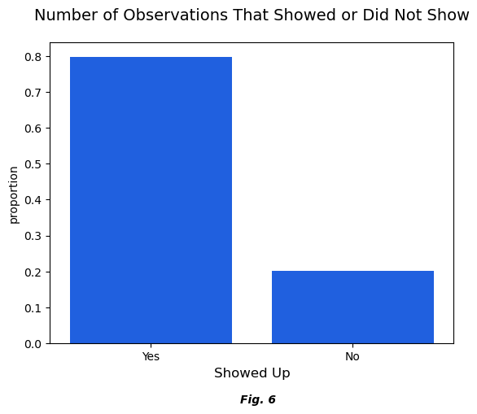

```python
# Visualize the number of no shows/shows

sns.countplot(data = no_show_data, x = no_show_data["Showed_up"], stat = "proportion", color = '#0056ff')
plt.xlabel("Showed Up", fontsize = 12)

# Get the current axis
ax = plt.gca()

# Get the maximum y-axis limit for positioning the text
y_max = ax.get_ylim()[1]
#print(y_max)

plt.text(x = 0.44, y = y_max * -0.2, s = "Fig. 6", fontstyle = "italic", fontweight = "demibold")
plt.title("Number of Observations That Showed or Did Not Show", fontsize = 14, pad = 20)
plt.show()
```

```python
no_show_data["Showed_up"].value_counts()
```

```
Yes    85307
No     21680
Name: Showed_up, dtype: int64
```

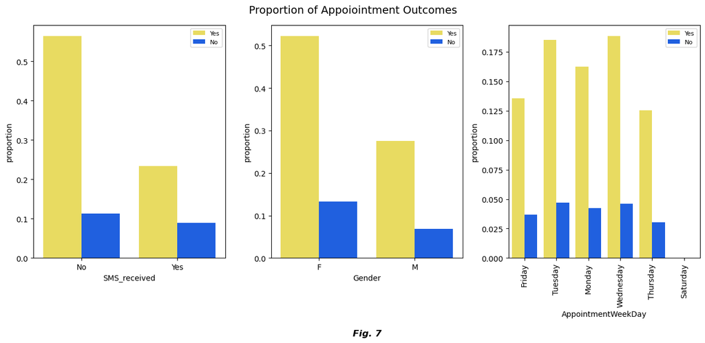

```python
# Visualize the counts of cateforical data - 5 rows, 4 columns

cols = ["SMS_received", "Gender", "AppointmentWeekDay"]

# Create plot
plt.figure(figsize = (13,6))

for i in range(len(cols)):
    if i < 2:
        plt.subplot(1,3,i+1)
        sns.countplot(data = no_show_data[["SMS_received", "Gender", "AppointmentWeekDay", "Showed_up"]],
                      x = cols[i],
                      hue = no_show_data["Showed_up"],
                      palette = ['#ffed4a', '#0056ff'], stat = "proportion")
        plt.legend(fontsize = 8)
    else:
        plt.subplot(1,3,i+1)
        sns.countplot(data = no_show_data[["SMS_received", "Gender", "AppointmentWeekDay", "Showed_up"]],
                      x = cols[i],
                      hue = no_show_data["Showed_up"],
                      palette = ['#ffed4a', '#0056ff'],
                      stat = "proportion")
                      #order = ["Monday", "Tuesday", "Wednesday", "Thursday", "Friday", "Saturday"])
        plt.xticks(rotation = 90)
        plt.legend(fontsize = 8)

plt.suptitle("Proportion of Appoiointment Outcomes",
            fontsize = 14)
plt.figtext(x = 0.5, y = -0.03, s = "Fig. 7", fontstyle = "italic", fontweight = "demibold", fontsize = 12)
plt.tight_layout()
```

```python
gender_gbo = no_show_data.groupby("Gender")["Showed_up"].value_counts()

gender_gbo
```

```
Gender  Showed_up
F       Yes          55843
        No           14275
M       Yes          29464
        No            7405
Name: Showed_up, dtype: int64
```

```python
print("FEMAL No Show Rate: ", gender_gbo[1] /(gender_gbo[0] + gender_gbo[1]))
print("MALE No Show Rate: ", gender_gbo[3] /(gender_gbo[2] + gender_gbo[3]))
```

[output not shown]

```python
sms_gbo = no_show_data.groupby("SMS_received")["Showed_up"].value_counts()

sms_gbo
```

```
SMS_received  Showed_up
No            Yes          60290
              No           12112
Yes           Yes          25017
              No            9568
Name: Showed_up, dtype: int64
```

```python
print("SMS_NO No Show Rate: ", sms_gbo[1] /(sms_gbo[0] + sms_gbo[1]))
print("SMS_YES No Show Rate: ", sms_gbo[3] /(sms_gbo[2] + sms_gbo[3]))
```

```
SMS_NO No Show Rate:  0.16728819645866136
SMS_YES No Show Rate:  0.2766517276275842
```

```python
apptday_gbo = no_show_data.groupby("AppointmentWeekDay")["Showed_up"].value_counts()

apptday_gbo
```

```
AppointmentWeekDay  Showed_up
Friday              Yes          14525
                    No            3940
Monday              Yes          17388
                    No            4515
Saturday            Yes             30
                    No               9
Thursday            Yes          13415
                    No            3244
Tuesday             Yes          19807
                    No            5024
Wednesday           Yes          20142
                    No            4948
Name: Showed_up, dtype: int64
```

```python
print("FRIDAY No Show Rate: ", apptday_gbo[1] /(apptday_gbo[0] + apptday_gbo[1]))
print("MONDAY No Show Rate: ", apptday_gbo[3] /(apptday_gbo[2] + apptday_gbo[3]))
print("SATURDAY No Show Rate: ", apptday_gbo[5] /(apptday_gbo[4] + apptday_gbo[5]))
print("THURSDAY No Show Rate: ", apptday_gbo[7] /(apptday_gbo[6] + apptday_gbo[7]))
print("TUESDAY No Show Rate: ", apptday_gbo[9] /(apptday_gbo[8] + apptday_gbo[9]))
print("WEDNESDAY No Show Rate: ", apptday_gbo[11] /(apptday_gbo[10] + apptday_gbo[11]))
```

```
FRIDAY No Show Rate:  0.21337665854318982
MONDAY No Show Rate:  0.20613614573346117
SATURDAY No Show Rate:  0.23076923076923078
THURSDAY No Show Rate:  0.1947295756047782
TUESDAY No Show Rate:  0.20232773549192543
WEDNESDAY No Show Rate:  0.1972100438421682
```

```python
# Very few observations that were recorded on Saturday.

no_show_data["AppointmentWeekDay"].value_counts()
```

```
Wednesday    25090
Tuesday      24831
Monday       21903
Friday       18465
Thursday     16659
Saturday        39
Name: AppointmentWeekDay, dtype: int64
```

```python
# Visualize the distribution of the amount of no shows no_show_data["Neighbourhood"].nunique()
```

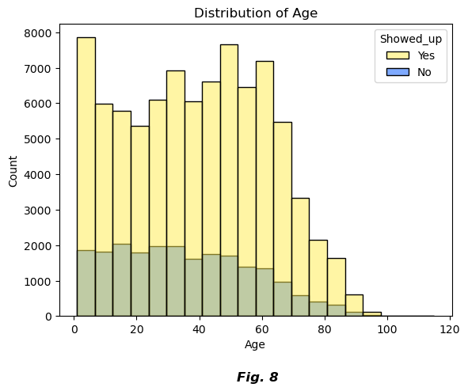

```python
# Visualize the distribution of age in the data set
sns.histplot(data = no_show_data,
             x = no_show_data["Age"],
             bins = 20,
             hue = no_show_data["Showed_up"],
             palette = ['#ffed4a','#0056ff'])

plt.title("Distribution of Age")
plt.figtext(x = 0.475, y = -0.06, s = "Fig. 8", fontstyle = "italic", fontweight = "demibold", fontsize = 12)
plt.show()
```

```python
# TOp 10 Neighborhoods with the most observations
no_show_data["Neighbourhood"].value_counts().nlargest(10)
```

```
JARDIM CAMBURI       7586
MARIA ORTIZ          5563
RESISTÊNCIA          4235
JARDIM DA PENHA      3851
ITARARÉ              3412
CENTRO               3282
SANTA MARTHA         3041
TABUAZEIRO           3019
JESUS DE NAZARETH    2719
BONFIM               2700
Name: Neighbourhood, dtype: int64
```

```python
# Create dummy variables to calculate the no show and show rate
dummies = pd.get_dummies(no_show_data["Showed_up"], drop_first=True)
no_show_data["Showed_up_dummies"] = dummies["Yes"]

# Calculate the no show rates for each Neighbourhood
no_show_gbo = no_show_data.groupby("Neighbourhood")["Showed_up_dummies"].agg(["sum","count"])
no_show_gbo["show_rate"] = (no_show_gbo["sum"]/no_show_gbo["count"]) * 100
no_show_gbo["no_show_rate"] = (1 - no_show_gbo["sum"]/no_show_gbo["count"]) * 100


no_show_gbo.sort_values("no_show_rate", ascending = False).head(10)
```

| Neighbourhood | sum | count | show_rate | no_show_rate |
| --- | --- | --- | --- | --- |
| ILHAS OCEÂNICAS DE TRINDADE | 0.0 | 2 | 0.000000 | 100.000000 |
| SANTOS DUMONT | 885.0 | 1249 | 70.856685 | 29.143315 |
| SANTA CECÍLIA | 323.0 | 443 | 72.911964 | 27.088036 |
| SANTA CLARA | 364.0 | 496 | 73.387097 | 26.612903 |
| ITARARÉ | 2514.0 | 3412 | 73.681125 | 26.318875 |
| JESUS DE NAZARETH | 2043.0 | 2719 | 75.137918 | 24.862082 |
| ILHA DO PRÍNCIPE | 1697.0 | 2222 | 76.372637 | 23.627363 |
| CARATOÍRA | 1903.0 | 2489 | 76.456408 | 23.543592 |
| ANDORINHAS | 1686.0 | 2195 | 76.810934 | 23.189066 |
| HORTO | 128.0 | 166 | 77.108434 | 22.891566 |

```python
no_show_gbo["no_show_rate"].describe()
```

```
count     81.000000
mean      20.531176
std        9.745963
min        0.000000
25%       17.857143
50%       19.585253
75%       21.919097
max      100.000000
Name: no_show_rate, dtype: float64
```

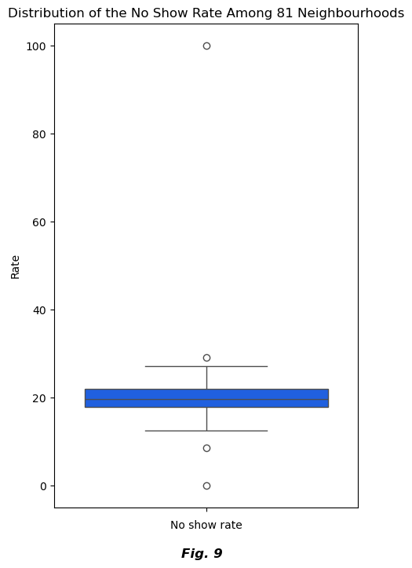

```python
plt.figure(figsize = (5, 8))
sns.boxplot(no_show_gbo["no_show_rate"], color = "#0056ff")
plt.xlabel("No show rate")
plt.ylabel("Rate")
plt.title("Distribution of the No Show Rate Among 81 Neighbourhoods")
plt.figtext(x = 0.45, y = 0.03, s = "Fig. 9", fontstyle = "italic", fontweight = "demibold", fontsize = 12)
plt.show()
```

## Modelling: Random Forest Classification

```python
# Bulding the model

# Import libraries/packages to build model and tree visualization
from sklearn.ensemble import RandomForestClassifier
from sklearn.model_selection import RandomizedSearchCV, train_test_split
from scipy.stats import randint

from sklearn.tree import export_graphviz
from IPython.display import Image
#import graphviz?
```

```python
no_show_data.head()
```

|  | Gender | ScheduledDay | AppointmentDay | Age | Neighbourhood | Scholarship | Hipertension | Diabetes | Alcoholism | Handcap | SMS_received | Showed_up | Date.diff | AppointmentWeekDay | ScheduledWeekDay | Showed_up_dummies |
| --- | --- | --- | --- | --- | --- | --- | --- | --- | --- | --- | --- | --- | --- | --- | --- | --- |
| 0 | F | 2016-04-29 | 2016-04-29 | 62 | JARDIM DA PENHA | No | Yes | No | No | No | No | Yes | 0 | Friday | Friday | 1 |
| 1 | M | 2016-04-29 | 2016-04-29 | 56 | JARDIM DA PENHA | No | No | No | No | No | No | Yes | 0 | Friday | Friday | 1 |
| 2 | F | 2016-04-29 | 2016-04-29 | 62 | MATA DA PRAIA | No | No | No | No | No | No | Yes | 0 | Friday | Friday | 1 |
| 3 | F | 2016-04-29 | 2016-04-29 | 8 | PONTAL DE CAMBURI | No | No | No | No | No | No | Yes | 0 | Friday | Friday | 1 |
| 4 | F | 2016-04-29 | 2016-04-29 | 56 | JARDIM DA PENHA | No | Yes | Yes | No | No | No | Yes | 0 | Friday | Friday | 1 |

```python
pd.get_dummies(no_show_data)
```

|  | ScheduledDay | AppointmentDay | Age | Date.diff | Showed_up_dummies | Gender_F | Gender_M | Neighbourhood_AEROPORTO | Neighbourhood_ANDORINHAS | Neighbourhood_ANTÔNIO HONÓRIO | ... | AppointmentWeekDay_Saturday | AppointmentWeekDay_Thursday | AppointmentWeekDay_Tuesday | AppointmentWeekDay_Wednesday | ScheduledWeekDay_Friday | ScheduledWeekDay_Monday | ScheduledWeekDay_Saturday | ScheduledWeekDay_Thursday | ScheduledWeekDay_Tuesday | ScheduledWeekDay_Wednesday |
| --- | --- | --- | --- | --- | --- | --- | --- | --- | --- | --- | --- | --- | --- | --- | --- | --- | --- | --- | --- | --- | --- |
| 0 | 2016-04-29 | 2016-04-29 | 62 | 0 | 1 | 1 | 0 | 0 | 0 | 0 | ... | 0 | 0 | 0 | 0 | 1 | 0 | 0 | 0 | 0 | 0 |
| 1 | 2016-04-29 | 2016-04-29 | 56 | 0 | 1 | 0 | 1 | 0 | 0 | 0 | ... | 0 | 0 | 0 | 0 | 1 | 0 | 0 | 0 | 0 | 0 |
| 2 | 2016-04-29 | 2016-04-29 | 62 | 0 | 1 | 1 | 0 | 0 | 0 | 0 | ... | 0 | 0 | 0 | 0 | 1 | 0 | 0 | 0 | 0 | 0 |
| 3 | 2016-04-29 | 2016-04-29 | 8 | 0 | 1 | 1 | 0 | 0 | 0 | 0 | ... | 0 | 0 | 0 | 0 | 1 | 0 | 0 | 0 | 0 | 0 |
| 4 | 2016-04-29 | 2016-04-29 | 56 | 0 | 1 | 1 | 0 | 0 | 0 | 0 | ... | 0 | 0 | 0 | 0 | 1 | 0 | 0 | 0 | 0 | 0 |
| ... | ... | ... | ... | ... | ... | ... | ... | ... | ... | ... | ... | ... | ... | ... | ... | ... | ... | ... | ... | ... | ... |
| 106982 | 2016-05-03 | 2016-06-07 | 56 | 35 | 1 | 1 | 0 | 0 | 0 | 0 | ... | 0 | 0 | 1 | 0 | 0 | 0 | 0 | 0 | 1 | 0 |
| 106983 | 2016-05-03 | 2016-06-07 | 51 | 35 | 1 | 1 | 0 | 0 | 0 | 0 | ... | 0 | 0 | 1 | 0 | 0 | 0 | 0 | 0 | 1 | 0 |
| 106984 | 2016-04-27 | 2016-06-07 | 21 | 41 | 1 | 1 | 0 | 0 | 0 | 0 | ... | 0 | 0 | 1 | 0 | 0 | 0 | 0 | 0 | 0 | 1 |
| 106985 | 2016-04-27 | 2016-06-07 | 38 | 41 | 1 | 1 | 0 | 0 | 0 | 0 | ... | 0 | 0 | 1 | 0 | 0 | 0 | 0 | 0 | 0 | 1 |
| 106986 | 2016-04-27 | 2016-06-07 | 54 | 41 | 1 | 1 | 0 | 0 | 0 | 0 | ... | 0 | 0 | 1 | 0 | 0 | 0 | 0 | 0 | 0 | 1 |

106987 rows × 114 columns

```python
# Features/Predictors
X_noshow = no_show_data[["Gender", "Age", "Neighbourhood", "Scholarship",
              "Hipertension", "Diabetes", "Alcoholism","Handcap",
              "SMS_received", "Date.diff", "AppointmentWeekDay",
              "ScheduledWeekDay"]]

X_noshow = pd.get_dummies(X_noshow)

# Target Variable
y_noshow = no_show_data["Showed_up"].map({'No':0,'Yes':1}).values
```

```python
# Split the data into training and test sets

X_noshow_train, X_noshow_test, y_noshow_train, y_noshow_test = train_test_split(X_noshow, y_noshow, test_size=0.2)
```

```python
y_noshow_train
```

```
array([1, 1, 1, ..., 1, 1, 1])
```

```python
# Create a random forest classification model and fit it to the training data

rf_model = RandomForestClassifier() # default n_estimators and depth
rf_model.fit(X_noshow_train, y_noshow_train)
```

```
RandomForestClassifier()
```

### Model Predictins and Evaluation

```python
# Use the testing set to predict outcome variable

y_pred_noshow = rf_model.predict(X_noshow_test)
```

```python
y_noshow_test
```

```
array([1, 0, 1, ..., 1, 1, 1])
```

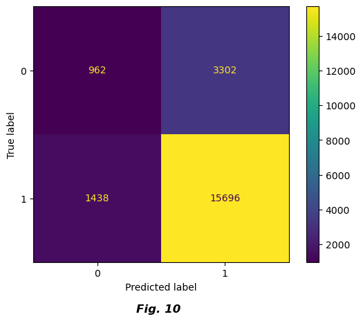

```python
# Visualize confusion matrix

# Create the confusion matrix
cm = confusion_matrix(y_noshow_test, y_pred_noshow)

ConfusionMatrixDisplay(confusion_matrix=cm).plot()
plt.figtext(x = 0.4, y = -0.04, s = "Fig. 10", fontstyle = "italic", fontweight = "demibold", fontsize = 12)
```

```python
# F1 Score
print("F1 score: ", f1_score(y_noshow_test, y_pred_noshow))

# Sensitivity - True Positive Rate - (TP/TP + FN)
# How many TP the model labeled incorrectly
print("Recall score: ", recall_score(y_noshow_test, y_pred_noshow))

# Precision -  Accuracy of predicting a predicted postive outcome (TP / TP + FP)
# How many Predicted positives were wrong
print("Precision score: ", precision_score(y_noshow_test, y_pred_noshow))

# Specificity - The proportion of negative classes that were correctly classified as negative (TN / TN + FP)
print("Specificity score: ", cm[0,0]/(cm[0,0] + cm[0,1]))

# Accuracy - The percent or proportion of cases classified corectly
print("Accuracy score: ", accuracy_score(y_noshow_test, y_pred_noshow))
```

```
F1 score:  0.8688143473928928
Recall score:  0.9160733045406794
Precision score:  0.8261922307611328
Specificity score:  0.22560975609756098
Accuracy score:  0.7784839704645294
```

```python
from sklearn.metrics import classification_report

print(classification_report(y_noshow_test, y_pred_noshow))
```

```
              precision    recall  f1-score   support

           0       0.40      0.23      0.29      4264
           1       0.83      0.92      0.87     17134

    accuracy                           0.78     21398
   macro avg       0.61      0.57      0.58     21398
weighted avg       0.74      0.78      0.75     21398
```

### Hyperparameter tuning and cross validation

```python
# Conduct hyperparameter tuning and compare models

param_dist = {'n_estimators': randint(50,500),
              'max_depth': randint(1,20)}

# Create a random forest classifier
rf_tuned = RandomForestClassifier()

# Use random search to find the best hyperparameters
rand_search = RandomizedSearchCV(rf_tuned,
                                 param_distributions = param_dist,
                                 n_iter=5,
                                 cv=5)

# Fit the random search object to the data
rand_search.fit(X_noshow_train, y_noshow_train)
```

```
RandomizedSearchCV(cv=5, estimator=RandomForestClassifier(), n_iter=5,
                   param_distributions={'max_depth': <scipy.stats._distn_infrastructure.rv_discrete_frozen object at 0x7fa059265910>,
                                        'n_estimators': <scipy.stats._distn_infrastructure.rv_discrete_frozen object at 0x7fa059d39d00>})
```

```python
# Create a variable for the best model
best_rf = rand_search.best_estimator_

# Print the best hyperparameters
print('Best hyperparameters:',  rand_search.best_params_)
```

```
Best hyperparameters: {'max_depth': 16, 'n_estimators': 363}
```

```
              precision    recall  f1-score   support

           0       0.60      0.01      0.02      4264
           1       0.80      1.00      0.89     17134

    accuracy                           0.80     21398
   macro avg       0.70      0.50      0.45     21398
weighted avg       0.76      0.80      0.72     21398
```

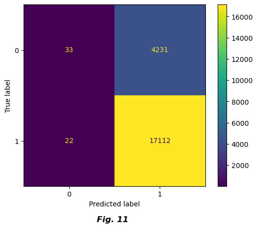

```python
# See how using the best model compares by generating predictions with the best model
y_pred_noshow_best = best_rf.predict(X_noshow_test)

# Create the confusion matrix
cm = confusion_matrix(y_noshow_test, y_pred_noshow_best)

print(classification_report(y_noshow_test, y_pred_noshow_best))

ConfusionMatrixDisplay(confusion_matrix=cm).plot()
plt.figtext(x = 0.4, y = -0.04, s = "Fig. 11", fontstyle = "italic", fontweight = "demibold", fontsize = 12)
```

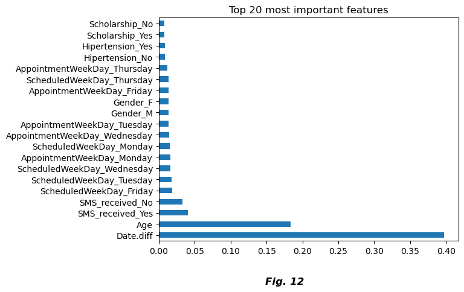

```python
# Plot feature importance

# Create a series containing feature importances from the model and feature names from the training data
feature_importances = pd.Series(best_rf.feature_importances_, index=X_noshow_train.columns).sort_values(ascending=False)

# Plot a simple bar chart to see the top 20 most important features
feature_importances.sort_values(ascending = False).head(20).plot(kind = "barh")
plt.title("Top 20 most important features")
plt.figtext(x = 0.4, y = -0.04, s = "Fig. 12", fontstyle = "italic", fontweight = "demibold", fontsize = 12)
plt.show()
```

## Modelling: AdaBoost

```python
# Build ada boost model
from sklearn.ensemble import AdaBoostClassifier
```

```python
# Create adaboost classifer object
abc = AdaBoostClassifier(n_estimators=50,
                         learning_rate=1)
# Train Adaboost Classifer
model = abc.fit(X_noshow_train, y_noshow_train)

#Predict the response for test dataset
y_pred_abc = model.predict(X_noshow_test)
```

```
              precision    recall  f1-score   support

           0       0.43      0.01      0.03      4264
           1       0.80      1.00      0.89     17134

    accuracy                           0.80     21398
   macro avg       0.61      0.50      0.46     21398
weighted avg       0.73      0.80      0.72     21398
```

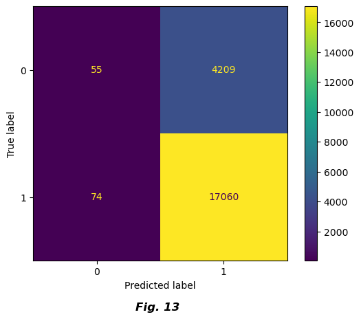

```python
# Create the confusion matrix
cm_abc = confusion_matrix(y_noshow_test, y_pred_abc)

ConfusionMatrixDisplay(confusion_matrix=cm_abc).plot()
plt.figtext(x = 0.4, y = -0.04, s = "Fig. 13", fontstyle = "italic", fontweight = "demibold", fontsize = 12)

print(classification_report(y_noshow_test, y_pred_abc))
```

This notebook was converted with convert.ploomber.io